# Lecture 4: Distributions

Author

POLS3316, Instructor: Tom Hanna, Spring 2025, University of Houston

Published

February 9, 2026

# Data Assumptions

## Why do we use data?

- Purpose: analyzing data for causal inference (to begin to make statements about cause and effect - inferring causes)
- Complex and uncertain data requires that we make…

## Assumptions about the data

- Because the world is complex, to make sense of unknowns we make assumptions about data
- The assumptions are useful approximations even when not precisely true
- We still need to check that the real data does not seriously violate the assumptions

## Data Assumptions: Random, Independent, and Identically Distributed

- Randomness and independence matter as assumptions about data
- Specifically, these are assumptions about the *Data Generating Process* or DGP
- The Data Generating Process: the way the world produces the data

## The Data Generating Process

- The source of the data matters - the DGP matters
- Previously stated: Data comes from a random world
- So the DGP is random

## Independence and Distribution

- Events in the data are *independent and identically distributed* - the IID assumption

## Statistical Independence

- Independence is statistical independence - the outcome of one event does not affect our belief about the probability of another event

  ```
  -   If we draw a number from a hat, then flip a coin, the hat draw does not affect the value of the coin toss
  -   X does not affect Y - the outcome of X does not affect our belief about the probability of Y
  ```

## What if X does affect Y?

If X does affect Y

- begin to infer a causal relationship
- possibly through one or more additional variables
- in some direction
- not necessarily that X causes Y
- *not quite accurate* summary “correlation does not imply causation”
- Better: *Correlation does not prove causation*

## Identically Distributed

- Identically distributed: drawn from the same *probability distribution*

So…

# Distributions

## Introduction to distributions

- R has functions for at least 20 *probability distributions*
- The most important is the *normal distribution*
- This is because of the *central limit theorem*
- We will look at these in the most detail: *normal*, *binomial*, *uniform*, *poisson*
- Because these are *probability distributions* they allow us to determine the probability that events are random chance or not

## Distribution examples

- The following are *histograms*
- They represent the *frequency* or simply the number count of observations for each value
- For example, if the value 4 shows 500, it means that 4 came up 500 times in the data
- The graphs were produced by generating random numbers based on the particular distribution with an R function

## Uniform distribution

**All outcomes are equally likely**

## Uniform distribution

**All outcomes are equally likely**

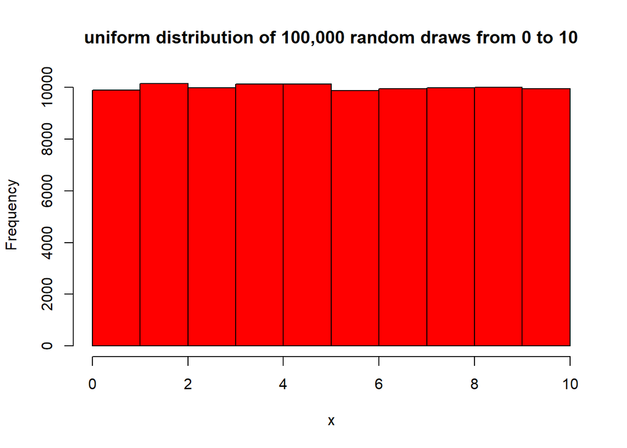

```r
# Set a seed for reproducibility

set.seed(123)

rand.unif <- runif(100000, min = 0, max = 10)
hist(rand.unif, breaks = 10, freq = TRUE, main = "uniform distribution of 100,000 random draws from 0 to 10", xlab = 'x', col = "red")
```

## Uniform Distribution: Probability

```
    - The probability of any frequency is 1/10
    - Any deviation from a value of 10,000 is a random deviation from the expected value
```

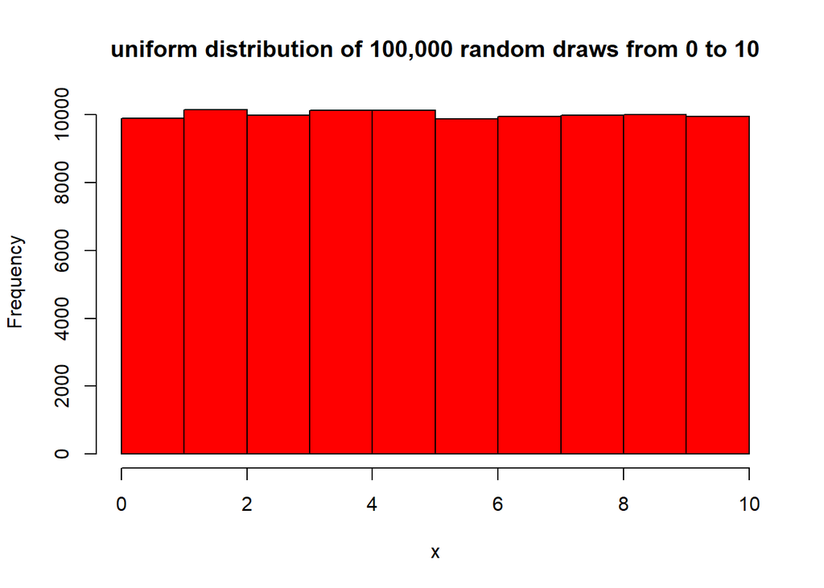

```r
# Set a seed for reproducibility

set.seed(123)

rand.unif <- runif(100000, min = 0, max = 10)
hist(rand.unif, breaks = 10, freq = TRUE, main = "uniform distribution of 100,000 random draws from 0 to 10", xlab = 'x', col = "red")
```

## Uniform distribution: with code

**All outcomes are equally likely**

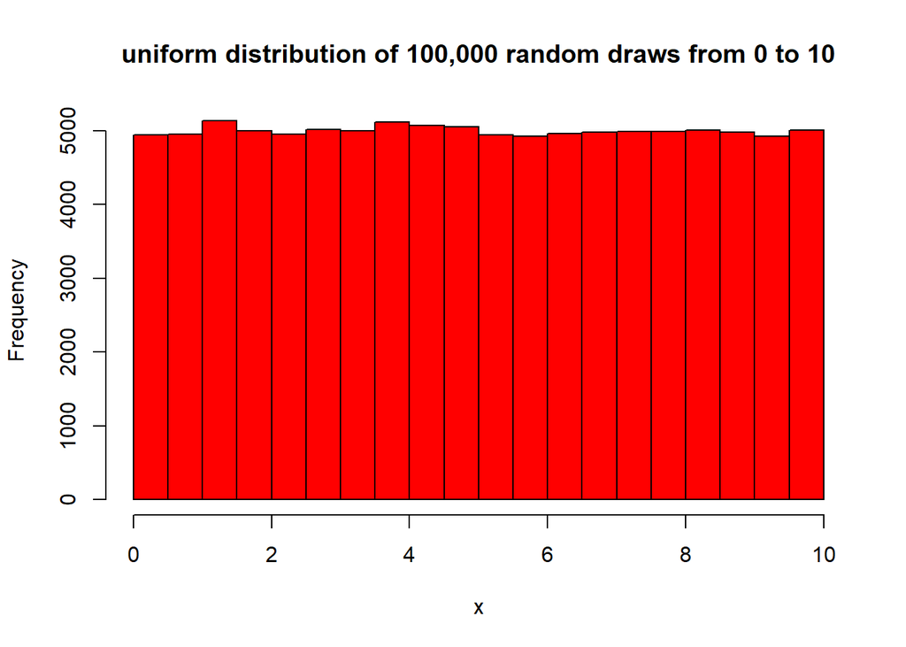

```r
# Set a seed for reproducibility

set.seed(123)

rand.unif <- runif(100000, min = 0, max = 10)
hist(rand.unif, breaks = 20, freq = TRUE, main = "uniform distribution of 100,000 random draws from 0 to 10", xlab = 'x', col = "red")
```

## Normal Distribution

- *symmetrical around its mean with most values near the central peak*
- width is a function of the *standard deviation*
- Other names: *Gaussian distribution*, *bell curve*

## Normal Distribution

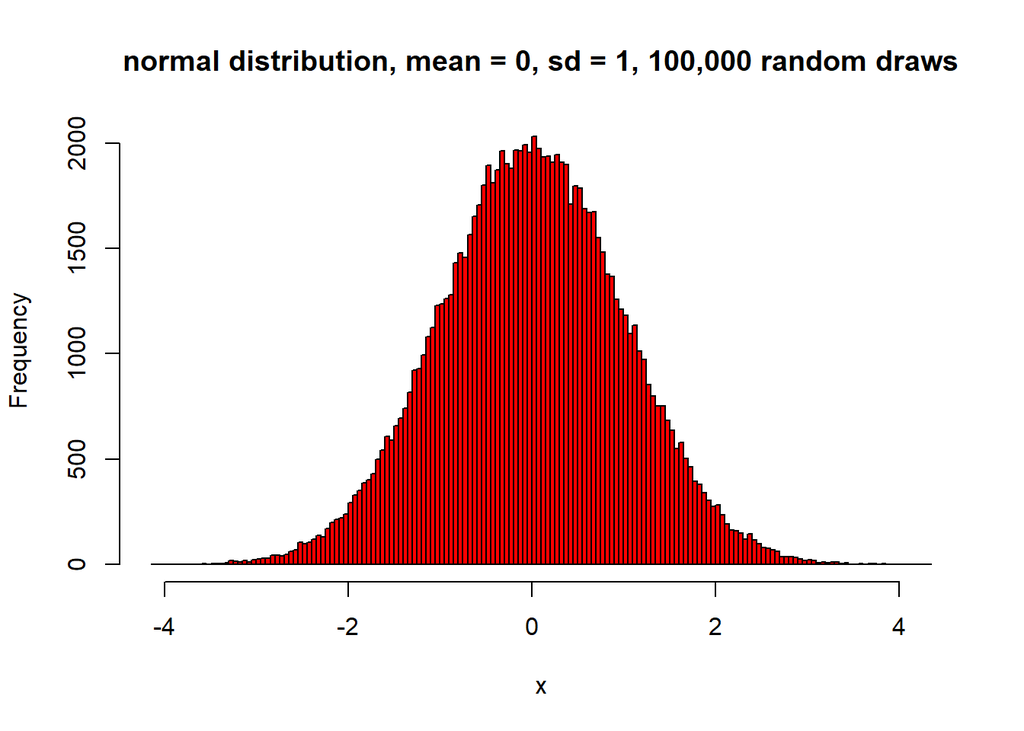

```r
set.seed(123)

rand.norm<- rnorm(100000)
hist(rand.norm, breaks = 200, freq = TRUE, main = "normal distribution, mean = 0, sd = 1, 100,000 random draws", xlab = 'x', col = "red")
```

## Normal Distribution: Probability

- The probability of a value is determined by how far it is from the mean in terms of standard deviations

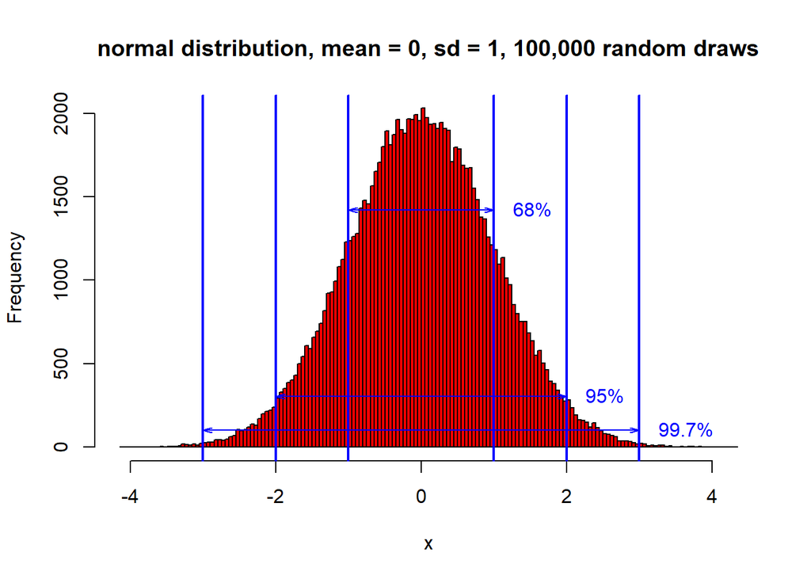

```r
set.seed(123)

# plot a normal distribution with mean = 0, sd = 1, 100,000 random draws, 200 breaks, and red color
# add lines to the plot to illustrate the 68-95-99.7 rule

rand.norm<- rnorm(100000)
h <- hist(rand.norm, breaks = 200, freq = TRUE, main = "normal distribution, mean = 0, sd = 1, 100,000 random draws", xlab = 'x', col = "red")
abline(v = c(-1, 1), col = "blue", lwd = 2)
abline(v = c(-2, 2), col = "blue", lwd = 2)
abline(v = c(-3, 3), col = "blue", lwd = 2)

# create labels to indicate the percentage within each range


# get max y from the histogram for label placement
ymax <- max(h$counts)

# add labels for the 68-95-99.7 rule

text(1.1, ymax*0.7, "68%",   pos = 4, col = "blue")
text(2.1, ymax*0.15, "95%",   pos = 4, col = "blue")
text(3.1, ymax*0.05, "99.7%", pos = 4, col = "blue")

# add arrows to illustrate the range of values within each standard deviation range

## arrows from +sd line to −sd line at same y-level
arrows(x0 = 1,  y0 = ymax*0.7, x1 = -1,  y1 = ymax*0.7,
       code = 3, angle = 15, length = 0.08, col = "blue")   # 68% range
arrows(x0 = 2,  y0 = ymax*0.15, x1 = -2,  y1 = ymax*0.15,
       code = 3, angle = 15, length = 0.08, col = "blue")   # 95% range
arrows(x0 = 3,  y0 = ymax*0.05, x1 = -3,  y1 = ymax*0.05,
       code = 3, angle = 15, length = 0.08, col = "blue")   # 99.7% range
```

## Normal Distribution: with code and probabilities

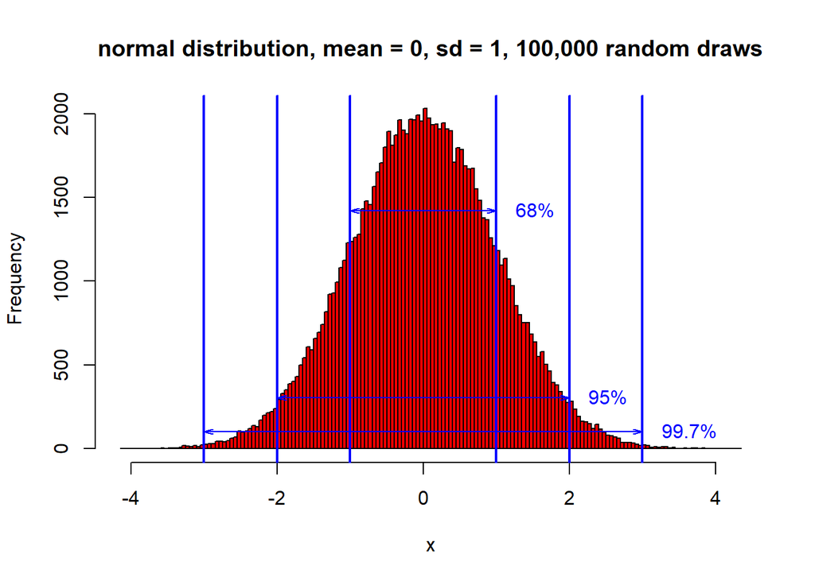

```r
set.seed(123)

# plot a normal distribution with mean = 0, sd = 1, 100,000 random draws, 200 breaks, and red color
# add lines to the plot to illustrate the 68-95-99.7 rule

rand.norm<- rnorm(100000)
h <- hist(rand.norm, breaks = 200, freq = TRUE, main = "normal distribution, mean = 0, sd = 1, 100,000 random draws", xlab = 'x', col = "red")
abline(v = c(-1, 1), col = "blue", lwd = 2)
abline(v = c(-2, 2), col = "blue", lwd = 2)
abline(v = c(-3, 3), col = "blue", lwd = 2)

# create labels to indicate the percentage within each range


# get max y from the histogram for label placement
ymax <- max(h$counts)

# add labels for the 68-95-99.7 rule

text(1.1, ymax*0.7, "68%",   pos = 4, col = "blue")
text(2.1, ymax*0.15, "95%",   pos = 4, col = "blue")
text(3.1, ymax*0.05, "99.7%", pos = 4, col = "blue")

# add arrows to illustrate the range of values within each standard deviation range

## arrows from +sd line to −sd line at same y-level
arrows(x0 = 1,  y0 = ymax*0.7, x1 = -1,  y1 = ymax*0.7,
       code = 3, angle = 15, length = 0.08, col = "blue")   # 68% range
arrows(x0 = 2,  y0 = ymax*0.15, x1 = -2,  y1 = ymax*0.15,
       code = 3, angle = 15, length = 0.08, col = "blue")   # 95% range
arrows(x0 = 3,  y0 = ymax*0.05, x1 = -3,  y1 = ymax*0.05,
       code = 3, angle = 15, length = 0.08, col = "blue")   # 99.7% range
```

## Binomial Distribution

- binary
- success/failure
- yes/no
- distribution for a number of Bernoulli trials

## Binomial - Bernoulli example

- n = 1 makes this a Bernoulli distribution

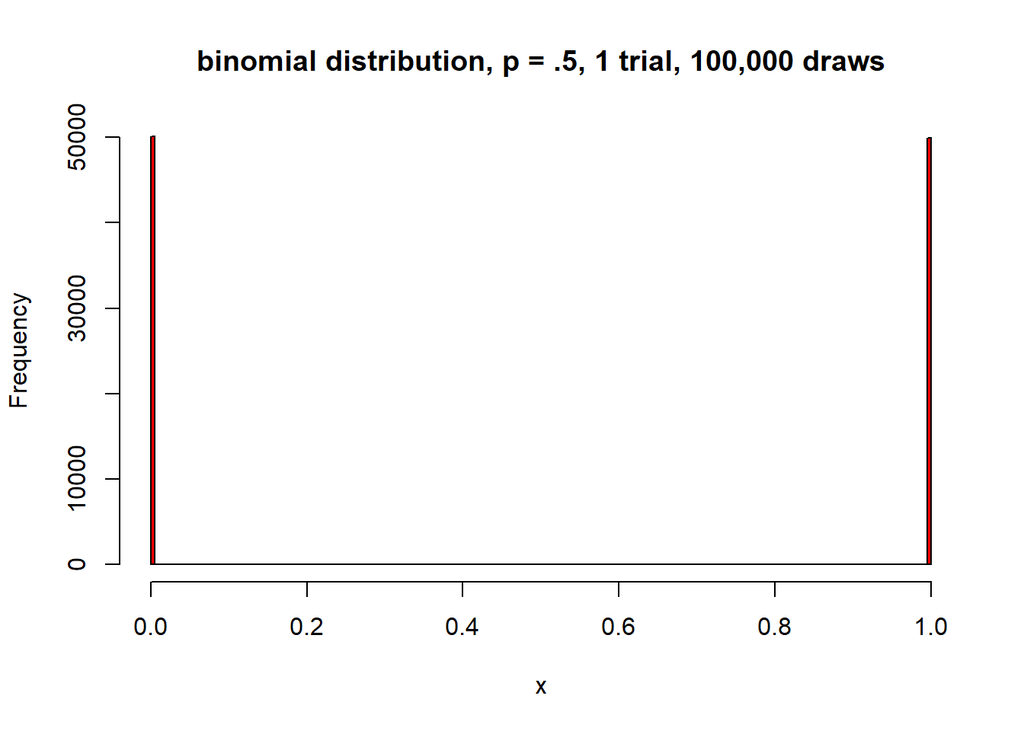

```r
rand.binom<- rbinom(100000,1,.5)
hist(rand.binom, breaks = 200, freq = TRUE, main = "binomial distribution, p = .5, 1 trial, 100,000 draws", xlab = 'x', col = "red")
```

## Binomial example: with code

- n = 1 makes this a Bernoulli distribution

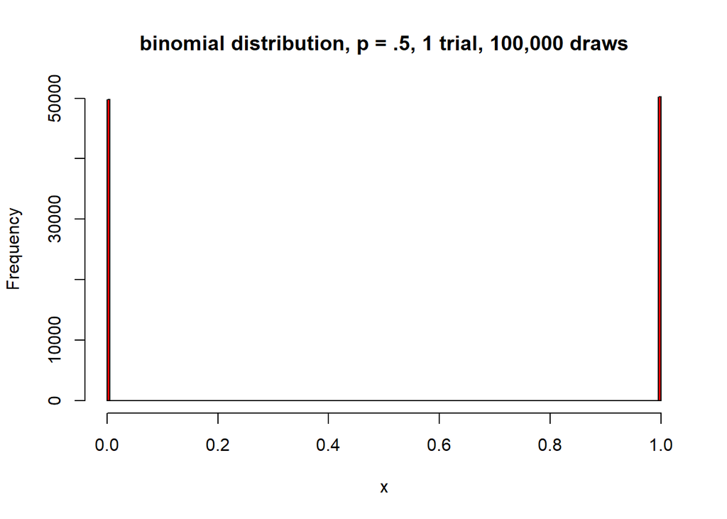

```r
rand.binom<- rbinom(100000,1,.5)
hist(rand.binom, breaks = 200, freq = TRUE, main = "binomial distribution, p = .5, 1 trial, 100,000 draws", xlab = 'x', col = "red")
```

## Binomial example: with code

- trials = 25

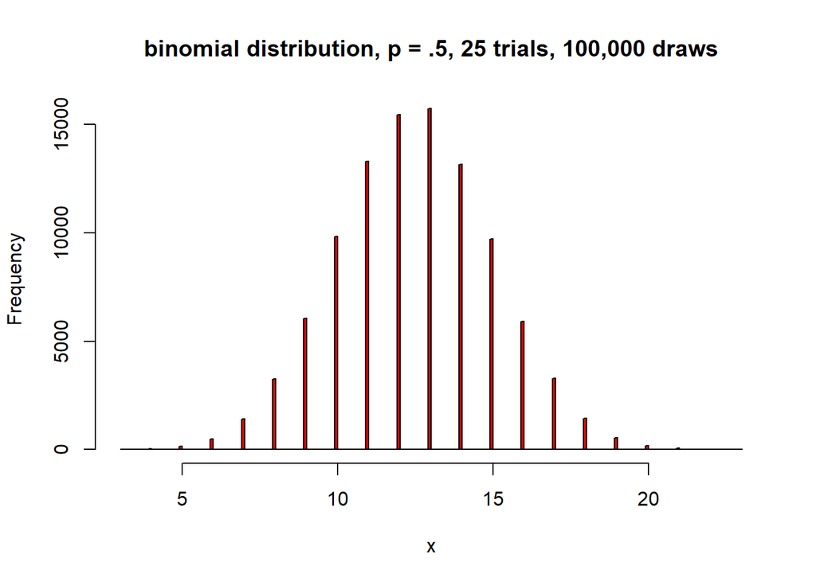

```r
rand.binom2 <- rbinom(100000,25,.5)
hist(rand.binom2, breaks = 200, freq = TRUE, main = "binomial distribution, p = .5, 25 trials, 100,000 draws", xlab = 'x', col = "red")
```

## Preview of the Central Limit Theorem

What happens if we do the same thing above but do it 1,000 times and plot the counts?

## Preview of the Central Limit Theorem

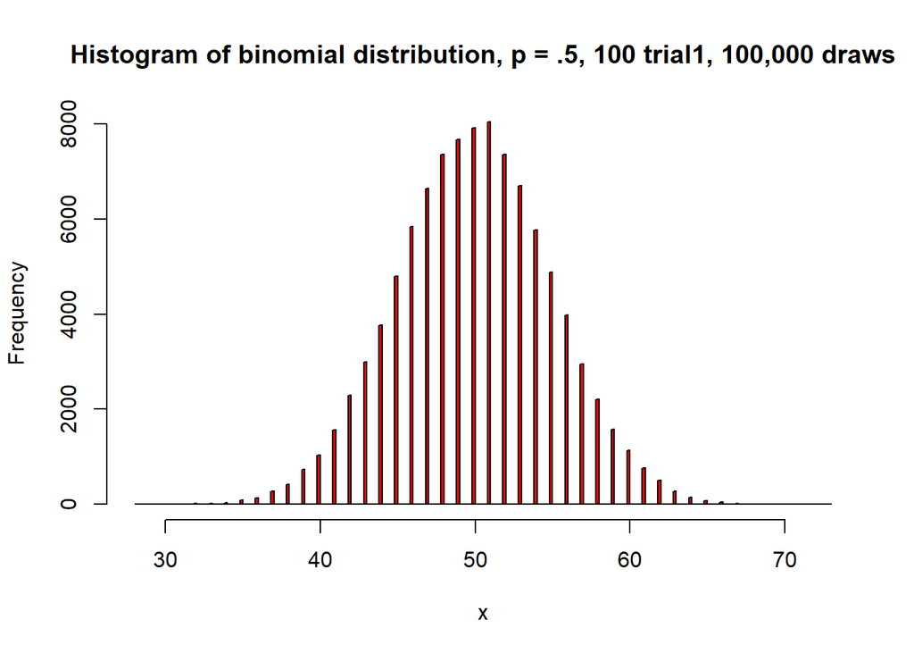

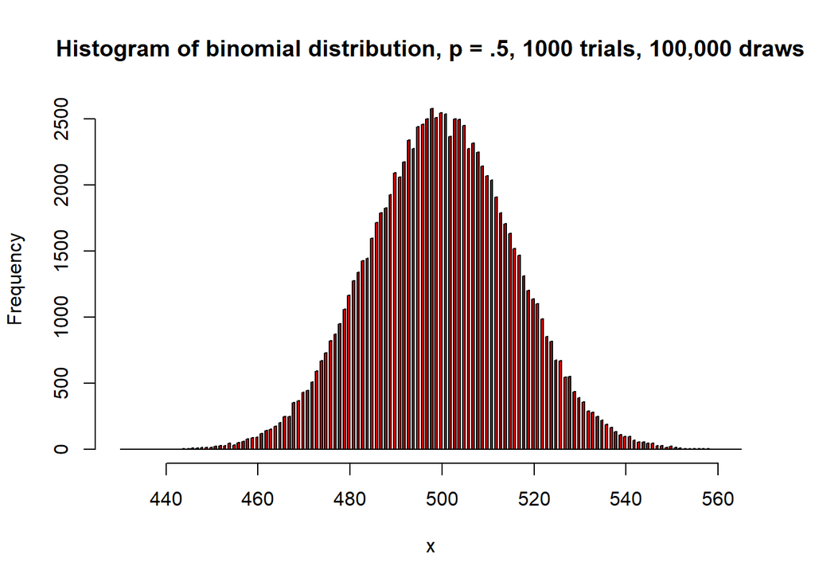

```r
rand.binom3<- rbinom(100000,100,.5)
hist(rand.binom3, breaks = 200, freq = TRUE, main = "Histogram of binomial distribution, p = .5, 100 trial1, 100,000 draws", xlab = 'x', col = "red")

rand.binom4<- rbinom(100000,1000,.5)
hist(rand.binom4, breaks = 200, freq = TRUE, main = "Histogram of binomial distribution, p = .5, 1000 trials, 100,000 draws", xlab = 'x', col = "red")
```

## Preview of the Central Limit Theorem: code

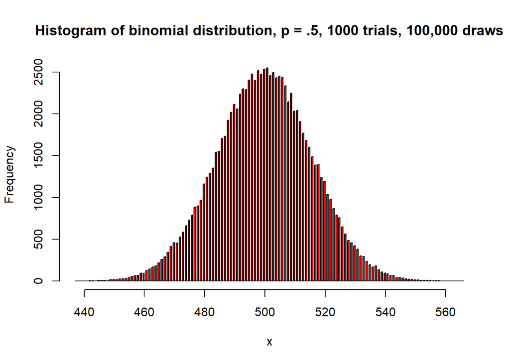

```r
rand.binom3<- rbinom(100000,1000,.5)
hist(rand.binom3, breaks = 200, freq = TRUE, main = "Histogram of binomial distribution, p = .5, 1000 trials, 100,000 draws", xlab = 'x', col = "red")
```

## Preview of the Central Limit Theorem

- For sufficiently large sample sizes, the distribution *of sample means* approximates a normal distribution
- This means with a large enough number of trials, we can apply the normal distribution to know things about measures of central tendency, measures of dispersion, and probabilities
- Sample sizes above 30
- This is just a preview

## 68-95-99.7 Rule

- One of the rules for normal distributions is:

The 68-95-99.7 rule

- 68% of the data is within 1 standard deviation of the mean
- 95% of the data is within 2 standard deviations of the mean
- 99.7% of the data is within 3 standard deviations of the mean

## Preview of the Law of Large Numbers

- The law of large numbers tells us that if we repeat an experiment a large number of time, the *average* of the results will be close to the expected value
- This allows us to apply the **actual mean of the sample** to the **expected mean of the population**
- We can treat the *statistics* of the sample as estimates of the *parameters* of the population

## Statistics and Parameters

- A *statistic* is a measure calculated from a sample of data

  ```
  - e.g., sample mean, sample variance, sample standard deviation
  ```

- A *parameter* is a measure calculated from the entire population

  ```
   - e.g., population mean, population variance, population standard deviation
  ```

## Poisson distribution

- *Count* of number of events in a fixed time/space
- *Known* constant mean rate of occurrence
- *Independent* of time since last event

## Poisson distribution

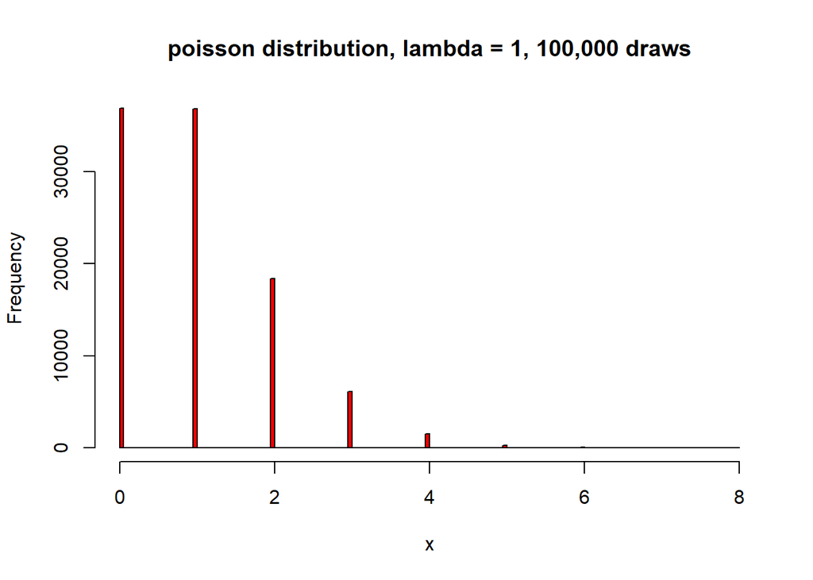

```r
set.seed(123)

rand.poiss<- rpois(100000,1)
hist(rand.poiss, breaks = 200, freq = TRUE, main = "poisson distribution, lambda = 1, 100,000 draws", xlab = 'x', col = "red")
```

## Poisson distribution: Assumptions

- The probability is different than the normal distribution
- lamda is both the mean and the variance of the distribution
- We don’t generally use standar deviation with Poisson
- The probabilities in the following example are specific to this setup with lambda = 1
- This is why count variables should not strictly be handled with *Ordinary Least Squares (OLS)* regression, which is the *linear regression* technique we will be using

## Poisson distribution: Probability

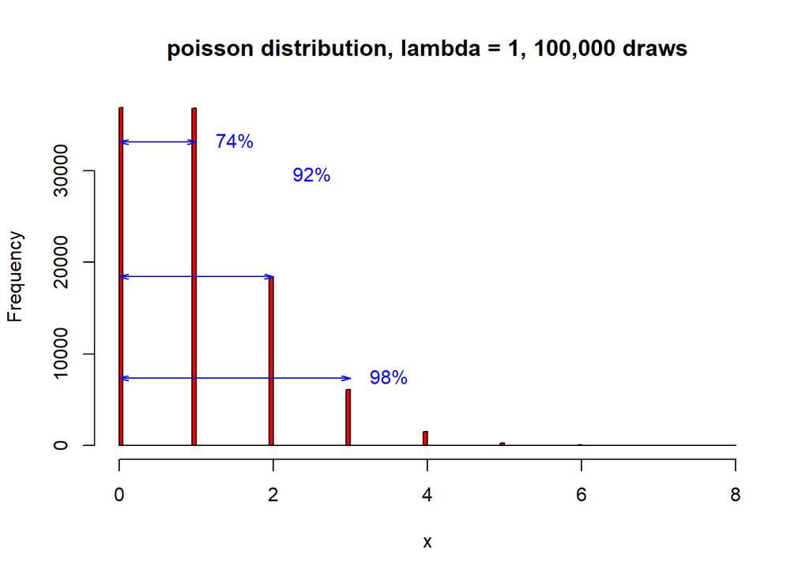

```r
set.seed(123)

rand.poiss<- rpois(100000,1)
hp <- hist(rand.poiss, breaks = 200, freq = TRUE, main = "poisson distribution, lambda = 1, 100,000 draws", xlab = 'x', col = "red")

# add lines to illustrate the probabilities of 0, 1, 2, and 3 events occurring

ypmax <- max(hp$counts)

# labels on the right
text(1.1, ypmax*0.9, "74%",   pos = 4, col = "blue")
text(2.1, ypmax*0.8, "92%",   pos = 4, col = "blue")
text(3.1, ypmax*0.2, "98%",   pos = 4, col = "blue")

# arrows spanning from 0 to each quantile line
arrows(x0 = 0.0, y0 = ypmax*0.9, x1 = 1, y1 = ypmax*0.9,
       code = 3, angle = 15, length = 0.08, col = "blue")
arrows(x0 = 0.0, y0 = ypmax*0.5, x1 = 2, y1 = ypmax*0.5,
       code = 3, angle = 15, length = 0.08, col = "blue")
arrows(x0 = 0.0, y0 = ypmax*0.2, x1 = 3, y1 = ypmax*0.2,
       code = 3, angle = 15, length = 0.08, col = "blue")
```

## Poisson distribution: with code

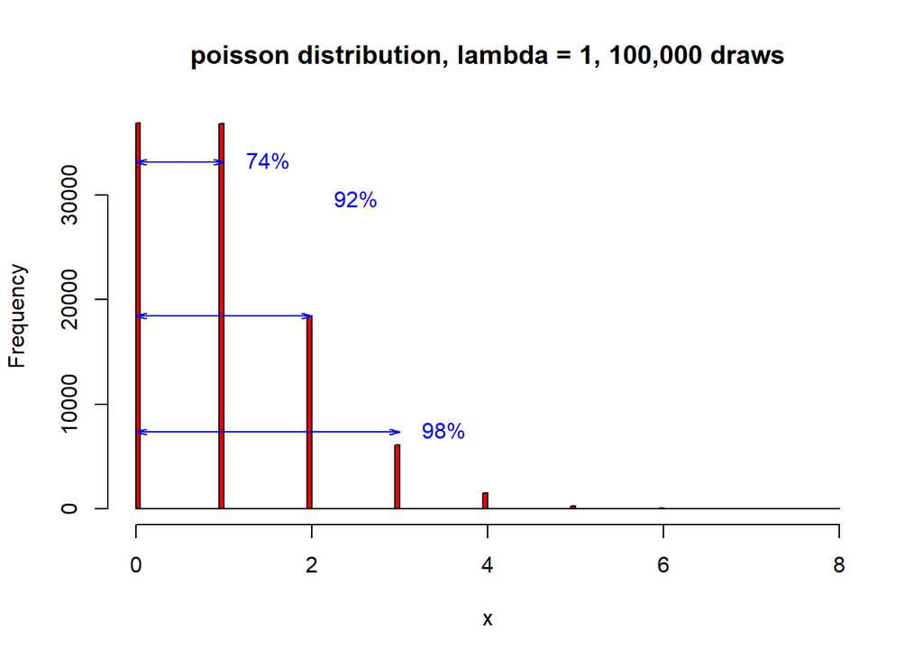

```r
set.seed(123)

rand.poiss<- rpois(100000,1)
hp <- hist(rand.poiss, breaks = 200, freq = TRUE, main = "poisson distribution, lambda = 1, 100,000 draws", xlab = 'x', col = "red")

# add lines to illustrate the probabilities of 0, 1, 2, and 3 events occurring

ypmax <- max(hp$counts)

# labels on the right
text(1.1, ypmax*0.9, "74%",   pos = 4, col = "blue")
text(2.1, ypmax*0.8, "92%",   pos = 4, col = "blue")
text(3.1, ypmax*0.2, "98%",   pos = 4, col = "blue")

# arrows spanning from 0 to each quantile line
arrows(x0 = 0.0, y0 = ypmax*0.9, x1 = 1, y1 = ypmax*0.9,
       code = 3, angle = 15, length = 0.08, col = "blue")
arrows(x0 = 0.0, y0 = ypmax*0.5, x1 = 2, y1 = ypmax*0.5,
       code = 3, angle = 15, length = 0.08, col = "blue")
arrows(x0 = 0.0, y0 = ypmax*0.2, x1 = 3, y1 = ypmax*0.2,
       code = 3, angle = 15, length = 0.08, col = "blue")
```

## Why we can’t use standard OLS regression for other DGP directly

- We base the likelihood of something being significant on the proximity to the mean
- As things get further from the mean in a normal distribution, they become less likely
- We can apply OLS to sample means of multiple trials because of the Central Limit Theorem
- For specific distributions, like Poisson, we have often have better techniques

## Why we don’t use standard OLS regression for other DGP: Example

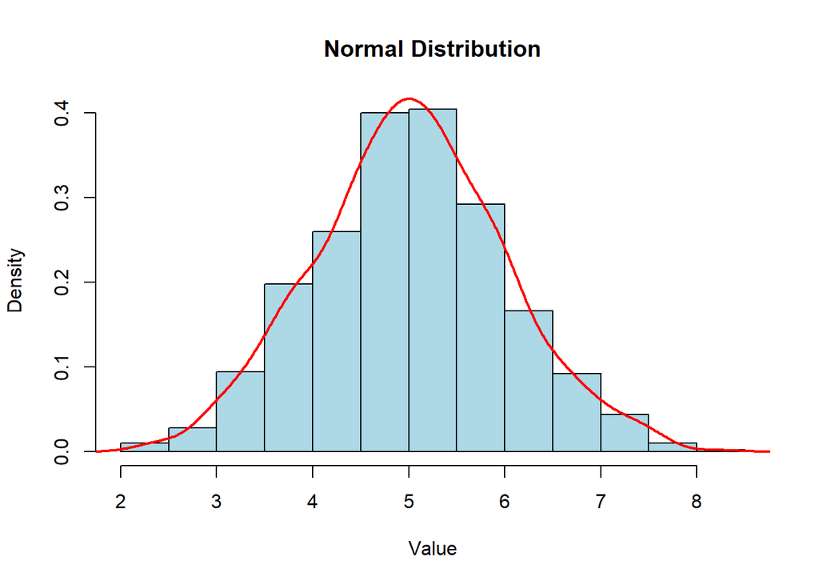

```r
# Set a seed for reproducibility
set.seed(123)

# Generate data for a normal distribution
mean_normal <- 5  # Mean of the normal distribution
sd_normal <- 1    # Standard deviation of the normal distribution
normal_data <- rnorm(1000, mean = mean_normal, sd = sd_normal)

# Create a histogram for the normal distribution
hist(normal_data, probability = TRUE, main = "Normal Distribution",
     xlab = "Value", ylab = "Density", col = "lightblue")

# Overlay a density plot for the normal distribution
lines(density(normal_data), col = "red", lwd = 2)
```

## Poisson vs. Normal Distribution

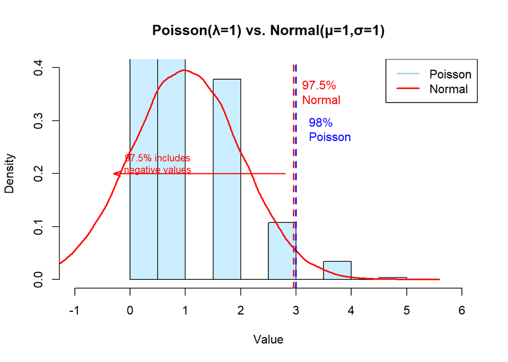

```r
# Set a seed for reproducibility
set.seed(123)

# Generate data
poisson_data <- rpois(1000, lambda = 1)
normal_data <- rnorm(100000, mean = 1, sd = 1)

# Create histogram for Poisson (density)
h <- hist(poisson_data, probability = TRUE,
          main = "Poisson(λ=1) vs. Normal(μ=1,σ=1)",
          xlab = "Value", ylab = "Density", ylim = c(0, 0.4),
          col = rgb(0.7, 0.9, 1, 0.7),
          xlim = c(-1, 6))  # extend x to show negatives

# Overlay normal density
lines(density(normal_data), col = "red", lwd = 2)

# Legend
legend("topright", legend = c("Poisson", "Normal"),
       col = c("lightblue", "red"), lty = 1, lwd = 2)

# Lines
abline(v = qnorm(0.975, 1, 1), col = "red", lwd = 2, lty = 2)  # ~2.96
abline(v = qpois(0.98, 1), col = "blue", lwd = 2, lty = 2)     # 3

# Labels
text(2.98, 0.35, "97.5%\nNormal", col = "red", pos = 4)
text(3.1,  0.28, "98%\nPoisson", col = "blue", pos = 4)

# Arrow pointing left from 97.5% line to negatives, with label
arrows(x0 = 2.8, y0 = 0.20, x1 = -0.3, y1 = 0.20,
       code = 2, angle = 20, length = 0.1, col = "red", lwd = 1.5)
text(0.5, 0.22, "97.5% includes\nnegative values", col = "red", cex = 0.8)
```

## Poisson v. Normal: Code

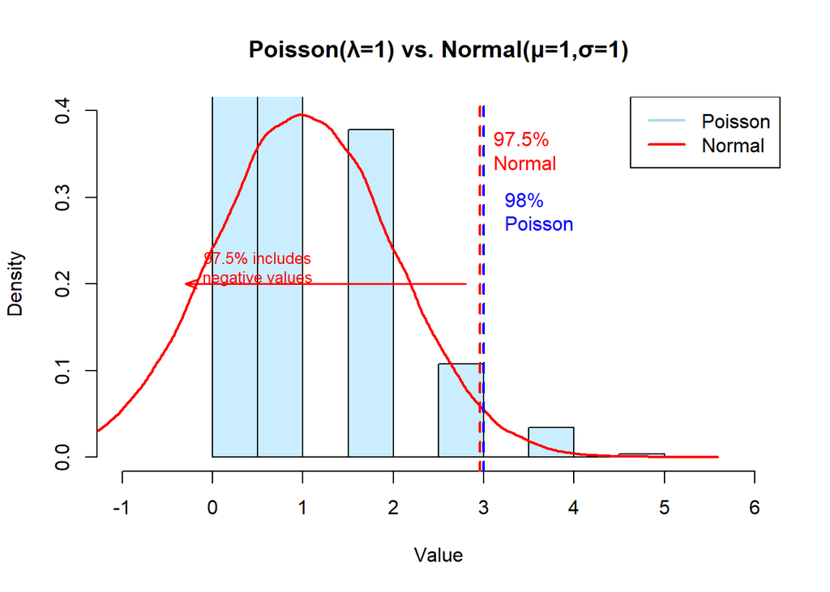

```r
# Set a seed for reproducibility
set.seed(123)

# Generate data
poisson_data <- rpois(1000, lambda = 1)
normal_data <- rnorm(100000, mean = 1, sd = 1)

# Create histogram for Poisson (density)
h <- hist(poisson_data, probability = TRUE,
          main = "Poisson(λ=1) vs. Normal(μ=1,σ=1)",
          xlab = "Value", ylab = "Density", ylim = c(0, 0.4),
          col = rgb(0.7, 0.9, 1, 0.7),
          xlim = c(-1, 6))  # extend x to show negatives

# Overlay normal density
lines(density(normal_data), col = "red", lwd = 2)

# Legend
legend("topright", legend = c("Poisson", "Normal"),
       col = c("lightblue", "red"), lty = 1, lwd = 2)

# Lines
abline(v = qnorm(0.975, 1, 1), col = "red", lwd = 2, lty = 2)  # ~2.96
abline(v = qpois(0.98, 1), col = "blue", lwd = 2, lty = 2)     # 3

# Labels
text(2.98, 0.35, "97.5%\nNormal", col = "red", pos = 4)
text(3.1,  0.28, "98%\nPoisson", col = "blue", pos = 4)

# Arrow pointing left from 97.5% line to negatives, with label
arrows(x0 = 2.8, y0 = 0.20, x1 = -0.3, y1 = 0.20,
       code = 2, angle = 20, length = 0.1, col = "red", lwd = 1.5)
text(0.5, 0.22, "97.5% includes\nnegative values", col = "red", cex = 0.8)
```

## Authorship and License

- Author: Tom Hanna
- Website: [tomhanna.me](https://tom-hanna.org/)
- License: This work is licensed under a [Creative Commons Attribution-NonCommercial-ShareAlike 4.0 International License.](http://creativecommons.org/licenses/by-nc-sa/4.0/)